### 🔍 Resumo do dia 27/08 📊💡📈🚀

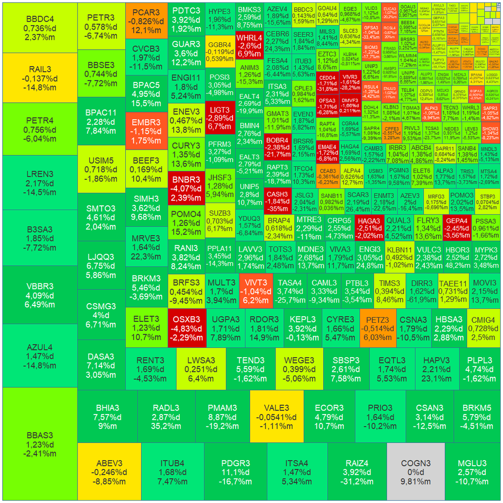

Maiores altas dos ativos mais representativos:

🟢 #VBBR3 4,09%  
🟢 #LREN3 2,17%  
🟢 #B3SA3 1,85%  
🟢 #AZUL4 1,47%  
🟢 #BBAS3 1,23%

Maiores quedas dos ativos mais representativos:

🔴 #OSXB3 -4,83%  
🔴 #EMBR3 -1,15%  
🔴 #PCAR3 -0,826%  
🔴 #ABEV3 -0,246%  
🔴 #RAIL3 -0,137%

### Veja a seguir os destaques desta quarta-feira, 27/08 📊💡📈🚀

[figure not shown]